# Replication of The Zero-Sum Fallacy in Evidence Evaluation by Pilditch, Fenton and Lagnado (2019, Psychological Science)

Philip Hernandez (philipah@stanford.edu)

December 14, 2019

## Repository

[Github repository](https://github.com/psych251/pilditch2019)

## Experimental Paradigm

[Qualtrics Survey](https://stanforduniversity.qualtrics.com/jfe/form/SV_2gK1VSf5qoa1q7z)

## Original Paper

[Pilditch, Fenton, and Lagnado (2019)](https://github.com/psych251/pilditch2019/tree/master/original_paper/pilditch2019.pdf)

## Introduction

My research interests lie in studying adult learning in the sciences, from the undergraduate sciences through medical school, especially where learning still takes place in lecture halls. However, I’m also interested in what neuroscience and the cognitive sciences can bring to this realm and what can be learned using these populations of post-secondary students. This study, though nominally part of this body of research does concern itself with the population I am interested in. In addition, I feel that in replicating this study, I would not only be able to hone skills necessary for processing data, but also explore an area of interest in my work. I find the underlying idea of the zero-sum fallacy something to be considered in educational assessment, even if the study is far removed from application in the classroom setting.

The study was originally performed using mTurk in three related experiments in which scenarios were described onscreen after which respondents answered questions indicating whether their judgment was “yes”, “no”, or “Cannot Tell”. The main difficulties would lie in recruiting, screening, and paying a large enough sample size- 25 people for experiment 1, 200 each in experiments 2 and 3. Beyond randomly assigning participants to groups and the experiment stimulus does not require specialized programming in mTurk. Storage, retrieval and analysis would pose a challenge, as I am not yet familiar with data storage and output from mTurk. As we seek to replicate only one experiment, I would be able to have enough productive struggle so that if in the future I wanted to replicate an entire studey I would be able to do so.

## Methods

### Power Analysis

The original effect size for each condition assuming an average value of (2 x 2 : Positive/Negative Result x control/Non-exhaustiveness statement) was as follows: Negative Control 0.777, Negative Non-exhaustiveness 1.847, Positive Control 0.348, and Positive Non-exhaustiveness 0.583.

Using the lowest and second lowest effect sizes. Power analyses were conducted to for 80%, 90%, 95% power to detect that effect size. Power analyses were calculated using G*Power 3.1.9.4 a-priori F-test family ANOVA: Fixed effects, special, main effects and interactions.

### Planned Sample

Planned sample is 58 English speaking Amazon Mechanical Turk workers from the United States with at least a 95% rating from more than 100 tasks.

Participants will be removed from the study for incomplete responses and if their native language is not English, similarly to methods reported in the original study.

### Materials

Materials from experiment will be used as indicated in Experiment 2 of Pilditch (2019) quoted below.

> "Each participant was assigned to one of two conditions: Either all scenarios contained positive test results or all contained negative test results. In all cases, there was both a target and an alternative explanation for the test result …

> “… To address the exhaustiveness issue, we introduced a between-subjects factor, in which an explicit statement regarding non-exhaustiveness was either present (non-exhaustiveness statement) or absent (control). This, in conjunction with the test-result between-subjects manipulation, led to a 2 × 2 design. The non-exhaustiveness statement preceded the standard judgment question and used the following structure: “Please note, it is possible that [subject] neither [Hypothesis 1] nor [Hypothesis 2].”

> “To address the confidence question, we included a confidence measure directly below the judgment question: “How confident are you that your response is correct?” Participants responded using a slider to indicate from 0% to 100% (no default value; for an example scenario, see Section C of the Supplemental Material)."

### Procedure

Procedures of experiment will be used as indicated in Experiment 2 of Pilditch (2019) quoted below.

> “Participants completed basic demographics (age, gender, native language) before moving on to the scenarios. Each participant completed the four scenarios … in a random order.”

> “For each scenario, participants were asked to make a judgment of “yes,” “no,” or “cannot tell” when posed with the following example format: “Does a [positive/negative] Griess test result give any support to the claim that Ann [has/has not] handled explosives?”

> “On a separate page, after each scenario judgment, participants were asked to “please briefly provide some reasoning for your decision regarding the previous scenario in the text box below” (not reported in this article). Along with demographics, scenario order and time taken were recorded."

> “Accordingly, as participants completed each of the four scenarios in random order, they made a judgment, expressed their confidence in that judgment, and then provided some reasoning.”

### Analysis Plan

*Descriptive Analysis* Data tables will include participant demographics, experimental conditions(order, positive/negative results, control/non-exhaustive statement), participant responses, time to respond, participant confidence ratings, and participant explanations.

*Bayesian Analysis* Mirroring the analysis done in Pilditch, Lagnado and Fenton (2019), I plan on conducting “a Bayesian analysis of variance (ANOVA) with test result and exhaustiveness manipulation (both between subjects)”. Data will be scored based on whether answer is correct (Yes = 1) or incorrect (Cannot Tell = 0, No = 0 ). For this, only the number of correct responses of each participant will be used as the dependent variable. Pilditch (2019) cites Dienes (2014) that a Bayes Factor of less than a third indicates strong support for the null hypothesis and a factor of greater than 3 represents substantial , therefore I will apply the same standard.

To determine effect size, a Bayesian one-sample t-test will be applied assessing difference from chance (1.33).

To examine confidence data, a 3 (judgement (Yes/No/Cannot Tell)) x 2 (test condition positive/neg ) x 2 (knowledge of exhaustiveness/control) ANOVA will be conducted.

Bayesian data analyses will be conducted in JASP first, similar to the experimental study then attempted in R for ease of replication.

### Differences from Original Study

Minor differences between the survey software used and the choices for demographic questions.

Qualtrics will be used in this survey.

In the original study participants were asked to choose a binary gender. In addition to the binary genders, I opted to allow for non-binary genders. For native language demographic, instead of choosing a language from a long drop-down list, I opted to list the five most common languages spoken in the US and an option to enter an language if it was not present. Likewise for the location question, I opted for the binary ‘In the United States’ versus ‘outside the United States’ with a text box to specify current location if this was not the case. I do not anticipate these modifications to change responses on the survey.

In addition, the demographic questions have been moved to the end of the survey to avoid any possible priming effects.

One factor that could impact results would be the decreased sample size. As the original sample size was 200, (50 per condition) the sample size we will use is 58 which will give about 14-15 per condition, but should yield significance in three of the four conditions. The sample is underpowered for the forth condition.

### Methods Addendum

#### Actual Sample

A sample size of 58 was obtained in December 2019 (24 Female, 34 Male). Mean age = 35.74 years, Median age = 34 years.

A cursory examination of explanations lead to one hit being rejected as they had provided one word answers to the explanation questions, the hit which was then taken up by another mTurker.

#### Differences from pre-data collection methods plan

I attempted to complete all analysis in R, however, was not able to and used JASP for some of the Bayesian Statistics.

## Results

### Data preparation

Data will be imported from Qualtrics via mTurk survey, extraneous data discarded and converted to long format from wide format for each of the analysis.

```r
### Data Preparation


#### Load Relevant Libraries and Functions
library(tidyr)
library(dplyr)
```

```r
library(stringr)
library(ggplot2)
library(readxl)
library(readr)
library(tibble)
library(BayesFactor) # For Bayes Factor ANOVA
library(knitr) #for table production in RMarkdown


#### Import data

Pilditch_exp2_replication <- read_excel("C:/Users/crazy/OneDrive/Desktop/Pilditch_exp2_replication.xlsx")

#pilot_1 used as intial variable name for backwards compatibilty purposes
pilot_1 <- Pilditch_exp2_replication

#### Data exclusion / filtering

pilot_rows12_removed <- pilot_1[-c(1,2),] # remove additional rows from qualtrics file

pilot_ids_added <- mutate(pilot_rows12_removed, "subid" = row_number() )# add subject id

filtered_pilot <- select(pilot_ids_added, subid, +contains("Nitro"), +contains("Ster"), +contains("BT"), +contains("Crash")) #remove extra qualtrics columns


exp2_filtered <- select(filtered_pilot, -contains("rn")) #remove reasoning for choice

exp2_decision <- select(exp2_filtered, -contains("%")) # only decisions retained

exp2_decision_long <- gather(exp2_decision, trial, value, Nitro_pos_ctrl: Crash_neg_ex, na.rm = TRUE) #convert to tidy/long data format, remove NAs

exp2_decision_long_mod <- exp2_decision_long %>%
  separate(trial, into = c("Scenario", "Result_given", "Condition"), sep = "_" ) #create varaibles for Scenario type, Result_give (pos/neg), and Condition (control/experimental)

exp2_decision_long_mod$Condition <-
  replace(exp2_decision_long_mod$Condition, exp2_decision_long_mod$Condition == "ex", "exp") #convert all "ex" nomenclature to "exp" nonmenclature for more descriptive variables, initial Qualtrics variables were character restricted

exp2_decision_long_mod$Scenario <-
  replace(exp2_decision_long_mod$Scenario, exp2_decision_long_mod$Scenario == "nitro", "Nitro") #convert all 'nitro' to 'Nitro'
```

#### Group data by condition, find mean proportions of each condition

```r
exp2_condition  <- subset(exp2_decision_long_mod, select = -Scenario ) #remove scenario column


exp2_condition_united <- unite(exp2_condition, united_subid_result_condition, subid, Result_given, Condition, sep = "-" ) #unite subid, Result_given, and Conidition into a single column so funcation as.data.frame can be used

exp2_condition_united_table <- as.data.frame(table(exp2_condition_united)) #counts all options (Yes, No, Cannot Tell) even when value = 0.


exp2_condition_subid <- separate(exp2_condition_united_table, united_subid_result_condition, into = c("subid", "Result_given", "Condition" ), sep = "-") #re-seperate out conditions for use as facets

exp2_proportions_by_subid <- mutate(exp2_condition_subid, prop = Freq/4 ) # calculation of proprotions
```

Confidence table data preparation

```r
exp2_confidence <- select(exp2_filtered, subid, contains("%")) # only confidence values retained from filtered dataset

exp2_confidence_long <- gather(exp2_confidence, trial, value, 'Nitro_pos_ctrl_%_1' : 'Crash_neg_ex_%_1' ,na.rm = TRUE) #convert to tidy/long data format, remove NAs

exp2_decision_confidence_long <-mutate(exp2_decision_long, confidence = exp2_confidence_long$value) #add long confidence data to decision data

exp2_decision_confidence_long <- exp2_decision_confidence_long %>%
  separate(trial, into = c("Scenario", "Result_given", "Condition"), sep = "_" ) #create varaibles for Scenario type, Result_give (pos/neg), and Condition (control/experimental)

exp2_decision_confidence_long$Condition <-
  replace(exp2_decision_confidence_long$Condition, exp2_decision_confidence_long$Condition == "ex", "exp") #convert all "ex" nomenclature to "exp" nonmenclature for more descriptive variables, initial Qualtrics variables were character restricted

exp2_decision_confidence_long$Scenario <-
  replace(exp2_decision_confidence_long$Scenario, exp2_decision_confidence_long$Scenario == "nitro", "Nitro") #convert all 'nitro' to 'Nitro'

exp2_decision_confidence_long$confidence <- as.numeric(exp2_decision_confidence_long$confidence) #convert confidence to numeric from character
```

Demographics

```r
Age_distribution <-summary(as.numeric(pilot_rows12_removed$Q78))
Gender_counts <- group_by(pilot_rows12_removed, Gender) %>%
  tally()
Age_distribution
```

```
##    Min. 1st Qu.  Median    Mean 3rd Qu.    Max.
##   22.00   29.00   34.00   35.74   38.75   67.00
```

```r
Gender_counts
```

```
## # A tibble: 2 x 2
##   Gender     n
##   <chr>  <int>
## 1 Female    24
## 2 Male      34
```

### Confirmatory analysis

#### Judgement Analysis

Means of proportions will be computed by grouping by test-result condition (variable defined as positive or negative) and further by control and Non-exhaustive Statement (variable defined as control_exhaustive and exp_N_exhaustive).

Calculate and graph means and standard deviations of each of the conditions

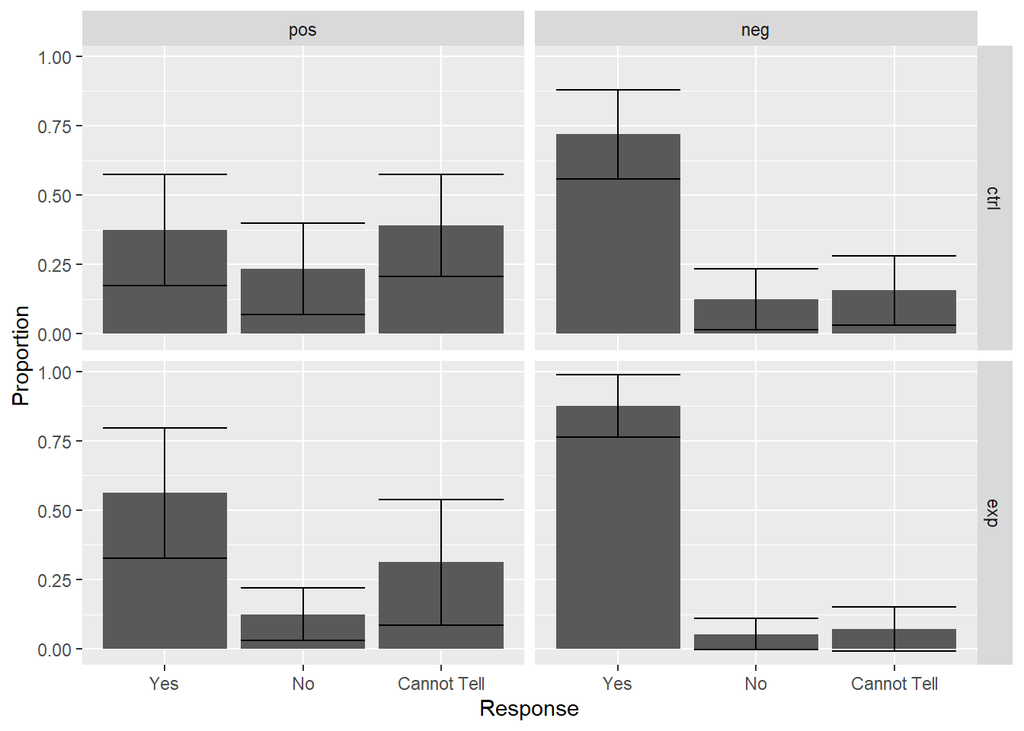

```r
exp2__decision_means <- exp2_proportions_by_subid %>%
  group_by(Result_given, Condition, value) %>%
 summarise(avg_prop = mean(prop), #store means
    u_interval = mean(prop) + 1.96*sd(prop)/sqrt(length(prop)), #upper bound of 95% CI
    l_interval = mean(prop) - 1.96*sd(prop)/sqrt(length(prop))) #lower bound of 95% CI

ggplot(transform(exp2__decision_means, Result_given=factor(Result_given, levels = c("pos", "neg")))) +  aes(value, avg_prop) + xlab("Response")+ ylab("Proportion") +
  geom_col(aes(x = value, y = avg_prop)) +
  scale_x_discrete(limits=c("Yes","No","Cannot Tell")) +
  geom_errorbar(aes (x = value, ymax = u_interval, ymin = l_interval))+
  facet_grid(Condition ~ Result_given)
```

Corresponding figure from Pilditch(2019) below:

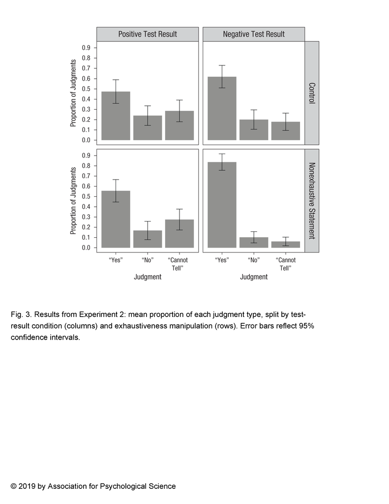

#### ANOVA Analysis

A Bayesian Analysis of Variance will be completed looking at test result (positive/negative) and presence of non-exhaustive statement (control_exhaustive and exp_N_exhaustive). Data will be scored based on whether answer is correct (Yes) or incorrect (Cannot Tell, No)

Bayesian ANOVA in R

```r
exp2_binary_result <- mutate(exp2_decision_long_mod, binary_result = ifelse(value == "Yes", 1, 0))
# convert answers to binary correct or incorrect

exp2_binary_cum_result_by_id <- group_by(exp2_binary_result, Result_given, Condition, subid) %>%  summarise (correct = sum(binary_result)) #calculate scores per subject

write.csv(exp2_binary_cum_result_by_id, file = "D://exp2_binary_cum_result_by_id.csv")

exp2_binary_summary_by_condition <- group_by(exp2_binary_cum_result_by_id, Result_given, Condition) %>%  summarise (mean_correct = mean(correct), sd_correct = sd(correct), n = length(correct)) # calculate mean, sd, and n

exp2_binary_summary_by_condition$`sd_correct`[is.nan(exp2_binary_summary_by_condition$`sd_correct`)] <- 0 # remove any Nan - only applicable in small samples

exp2_binary_cum_result_by_id$Condition = factor(exp2_binary_cum_result_by_id$Condition) #encode Condition as factor
exp2_binary_cum_result_by_id$Result_given = factor(exp2_binary_cum_result_by_id$Result_given) #encode Result_given as factor

exp2.aov <- anovaBF(correct ~ Condition*Result_given,  data = exp2_binary_cum_result_by_id)
exp2.aov
```

```
## Bayes factor analysis
## --------------
## [1] Result_given                                      : 44.92491 ±0%
## [2] Condition                                         : 1.052825 ±0.01%
## [3] Result_given + Condition                          : 51.54268 ±0.68%
## [4] Result_given + Condition + Result_given:Condition : 18.07407 ±1.02%
##
## Against denominator:
##   Intercept only
## ---
## Bayes factor type: BFlinearModel, JZS
```

Compare to results from JASP:

```r
Jasp_BF_results <-data.frame(Models = c("Null model", "Result_given + Condition",                             "Result_given", "Result_given + Condition + Result_given*Condition", "Condition"), BF10 = c(1.000, 52.260, 44.925,18.403, 1.053))

knitr::kable(Jasp_BF_results, caption = "Bayes Factors when compared to null model")
```

Bayes Factors when compared to null model

| Models | BF10 |
| --- | --- |
| Null model | 1.000 |
| Result_given + Condition | 52.260 |
| Result_given | 44.925 |
| Result_given + Condition + Result_given*Condition | 18.403 |
| Condition | 1.053 |

Calculate summary Statistics

```r
exp_2_summary_table <-group_by(exp2_binary_cum_result_by_id, Result_given, Condition) %>%
         summarise(Mean = mean(correct), SD = sd(correct), N = n())
```

Add Results from Bayesian one-sample t-test

Used Data from JASP, as I was not able to reproduce original Bayesian one-sample t-test using R.

```r
BF = c(117.127, 47443.707, 1.155, 6.276) # imported from JASP
exp_2_summary_table_wBF <- add_column(exp_2_summary_table, BF10 = BF)
knitr::kable(exp_2_summary_table_wBF, caption = "Descriptive Statistics and Bayes Factors from Bayesian One-Sample T-Tests")
```

Descriptive Statistics and Bayes Factors from Bayesian One-Sample T-Tests

| Result_given | Condition | Mean | SD | N | BF10 |
| --- | --- | --- | --- | --- | --- |
| neg | ctrl | 2.875 | 1.3102163 | 16 | 117.127 |
| neg | exp | 3.500 | 0.8548504 | 14 | 47443.707 |
| pos | ctrl | 1.500 | 1.6329932 | 16 | 1.155 |
| pos | exp | 2.250 | 1.6583124 | 12 | 6.276 |

*As I have not yet been able to reproduce the Cohen’s-d values nor the 95% Credibility interval in the original paper, I am not using these statistics as a basis of comparison.*

Corresponding Table from Pilditch(2019) below:

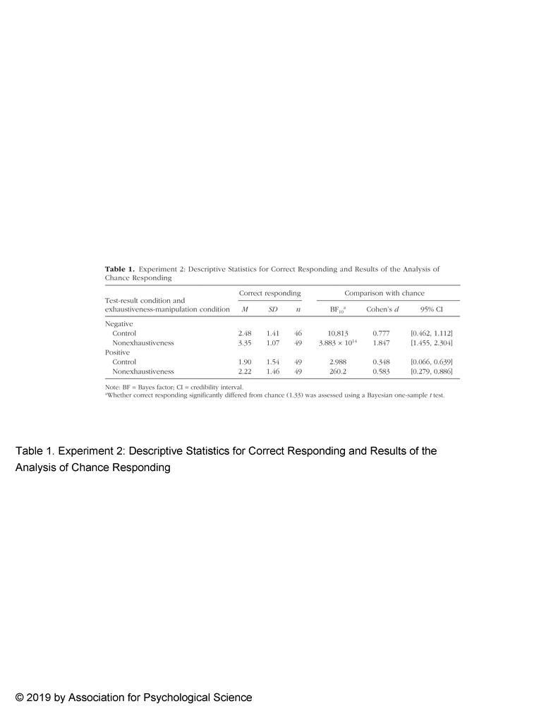

#### Confidence Analysis

Means of confidence in judgments will be computed by grouping by test-result condition (variable defined as positive or negative) and further by control and Non-exhaustive Statement (variable defined as control_exhaustive and exp_N_exhaustive). Graph will be displayed as a box and whisker plot.

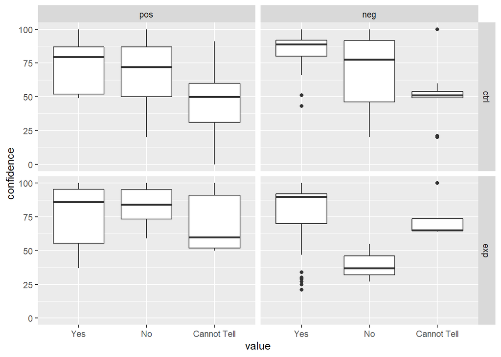

```r
ggplot(transform(exp2_decision_confidence_long,
                 Result_given=factor(Result_given, levels = c("pos", "neg"))),
       aes(x = value, y = confidence)) +
geom_boxplot() +
scale_x_discrete(limits=c("Yes","No","Cannot Tell")) +
facet_grid(Condition ~ Result_given)
```

Corresponding figure from Pilditch(2019) below:

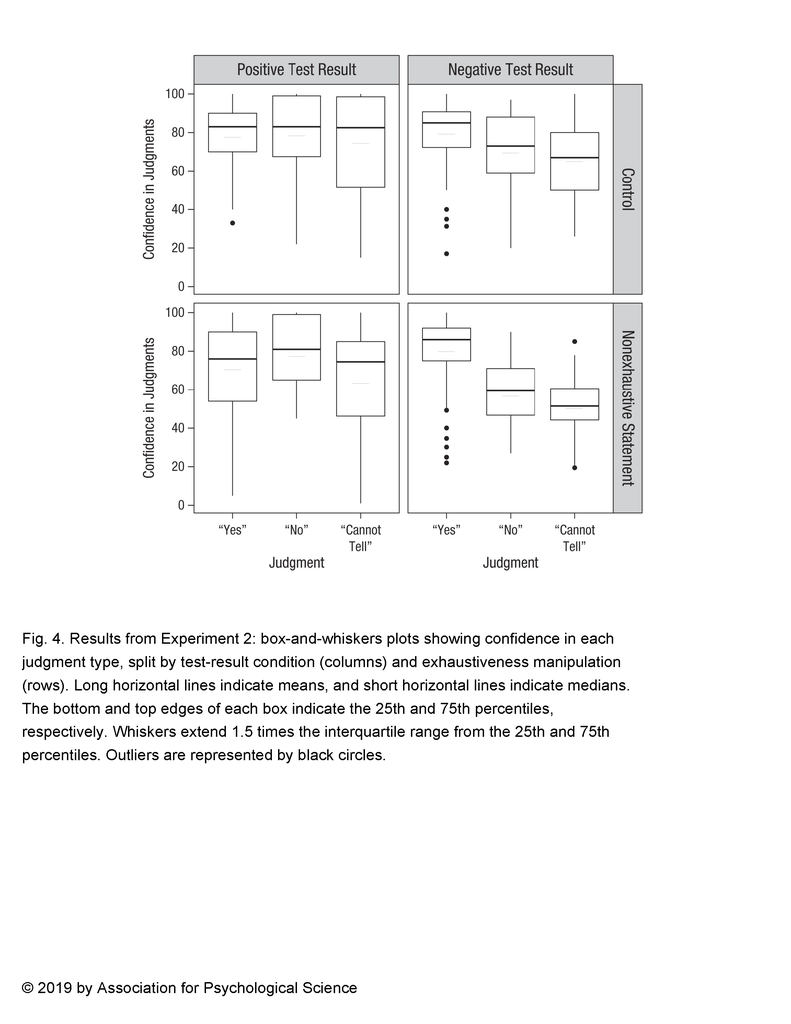

## Discussion

### Summary of Replication Attempt

The study partially replicated the result, as some results replicated and others did not approach significance.

For the data analyzed the Result_given (Positive vs. Negative Test Result) did have a higher BF inclusion value (46.493) than the Condition’s (Control vs. Experimental) BF inclusion value (1.123). When compared with the original study (BF inclusion - Result_given + 607.57, Condition 9.02) this second value did not reach the initial significance of the original study. The model using both factors was considered the best fit overall and was significant. Data for confidence ratings was not analyzed due to difficulties reproducing the statistical analysis in R and JASP.

### Commentary

I had already anticipated not replicating one of the results due to the replication attempt being under-powered, so a partial replication did not come as a surprise. I doubt the movement of the demographic question to the end of the survey caused any significant change in responses, but that is one factor to keep in mind when analyzing the replication. From a best-practices perspective, the results in the replication are less likely to have been biased due to a possible priming effect from the demographic question.

The biggest personal difficulty was attempting to do the analysis in R when the authors had used a different program (JASP) to analyze their results, as the different programs have different terminology for reporting Bayes Factors, leading me to attempt to reproduce the original results in JASP, then attempt to reproduce them in R and link the categorization of variables.